# Layoff_Final_Analysis

pg611@scarletmail.rutgers.edu

2024-04-29

```r
library(MASS)
library(ggplot2)
library(memisc)
library(ROCR)
library(dplyr)
library(klaR)
library(memisc)
library(ggplot2)
library(corrplot)
library(factoextra)
library(psych)
library(NbClust)
library(caTools)
library(magrittr)
library(pROC)
library(caret)


sc_dataset <- read.csv("/Users/parul/OneDrive/Desktop/MVA/Layoff_Data.csv", row.names=1)
str(sc_dataset)
```

```
## 'data.frame':    50 obs. of  9 variables:
##  $ Laid_Off             : int  200 100 350 100 900 130 235 225 15 839 ...
##  $ Percentage           : int  15 20 10 12 24 29 16 11 33 100 ...
##  $ Before_Layoffs       : int  1333 500 3500 1000 3750 450 1567 2045 45 839 ...
##  $ After_layoffs        : int  1133 400 3150 900 2850 320 1332 1820 30 0 ...
##  $ Money_Raised_in_._mil: int  1700 733 116 1500 15000 1300 2500 97 302 194 ...
##  $ lat                  : num  13 32.8 37.5 13 37.8 ...
##  $ lng                  : num  77.6 35 -122 77.6 -122.4 ...
##  $ layoff               : int  1 0 1 0 1 0 1 1 0 1 ...
##  $ Laid_Off_Yes_No      : chr  "Yes" "No" "Yes" "No" ...
```

# DATA COLLECTION :

- Source: Kaggle
- Dataset Name: Layoffs Dataset
- URL: https://www.kaggle.com/datasets/swaptr/layoffs-2022
- Description: The dataset was retrieved from Kaggle, a platform known for hosting datasets and machine learning competitions. It contains information on layoffs within the technology industry, including various attributes such as company name, number of layoffs, percentage of employees laid off, financial metrics, geographic location, and more.

# DATA DICTIONARY :

- Company: Name of the technology company.
- Laid_Off: Number of employees laid off.
- Percentage: Percentage of employees laid off.
- Before_Layoffs: Number of employees before the layoffs.
- After_layoffs: Number of employees after the layoffs.
- Money_Raised_in_$_mil: Amount of money raised by the company in millions (in $).
- lat: Latitude coordinate of the company’s location.
- lng: Longitude coordinate of the company’s location.
- layoff: Binary indicator of layoffs (1 for layoffs, 0 for no layoffs).
- Laid_Off_Yes_No: Categorical indicator of layoffs (Yes for layoffs, No for no layoffs).

# QUESTIONS and HYPOTHESIS Questions :

- What are the key factors contributing to layoffs in the technology industry?
- How accurately can we predict the likelihood of future layoffs in tech companies based on historical data?

# Analysis and Visualization :

```r
str(sc_dataset)
```

```
## 'data.frame':    50 obs. of  9 variables:
##  $ Laid_Off             : int  200 100 350 100 900 130 235 225 15 839 ...
##  $ Percentage           : int  15 20 10 12 24 29 16 11 33 100 ...
##  $ Before_Layoffs       : int  1333 500 3500 1000 3750 450 1567 2045 45 839 ...
##  $ After_layoffs        : int  1133 400 3150 900 2850 320 1332 1820 30 0 ...
##  $ Money_Raised_in_._mil: int  1700 733 116 1500 15000 1300 2500 97 302 194 ...
##  $ lat                  : num  13 32.8 37.5 13 37.8 ...
##  $ lng                  : num  77.6 35 -122 77.6 -122.4 ...
##  $ layoff               : int  1 0 1 0 1 0 1 1 0 1 ...
##  $ Laid_Off_Yes_No      : chr  "Yes" "No" "Yes" "No" ...
```

```r
summary(sc_dataset)
```

```
##     Laid_Off        Percentage     Before_Layoffs    After_layoffs
##  Min.   :  15.0   Min.   :  1.00   Min.   :   45.0   Min.   :    0.0
##  1st Qu.:  80.0   1st Qu.: 10.00   1st Qu.:  375.0   1st Qu.:  207.8
##  Median : 130.0   Median : 16.50   Median :  879.5   Median :  719.0
##  Mean   : 248.1   Mean   : 22.18   Mean   : 2387.0   Mean   : 2139.0
##  3rd Qu.: 246.2   3rd Qu.: 25.00   3rd Qu.: 2570.2   3rd Qu.: 2481.8
##  Max.   :1500.0   Max.   :100.00   Max.   :22000.0   Max.   :21340.0
##  Money_Raised_in_._mil      lat              lng              layoff
##  Min.   :    3.0       Min.   : 8.496   Min.   :-126.42   Min.   :0.00
##  1st Qu.:  101.5       1st Qu.:37.358   1st Qu.:-122.40   1st Qu.:0.00
##  Median :  378.0       Median :37.775   Median :-115.62   Median :0.00
##  Mean   : 1020.0       Mean   :37.535   Mean   : -73.36   Mean   :0.36
##  3rd Qu.: 1100.0       3rd Qu.:40.749   3rd Qu.: -71.08   3rd Qu.:1.00
##  Max.   :15000.0       Max.   :59.329   Max.   :  77.59   Max.   :1.00
##  Laid_Off_Yes_No
##  Length:50
##  Class :character
##  Mode  :character
##
##
##
```

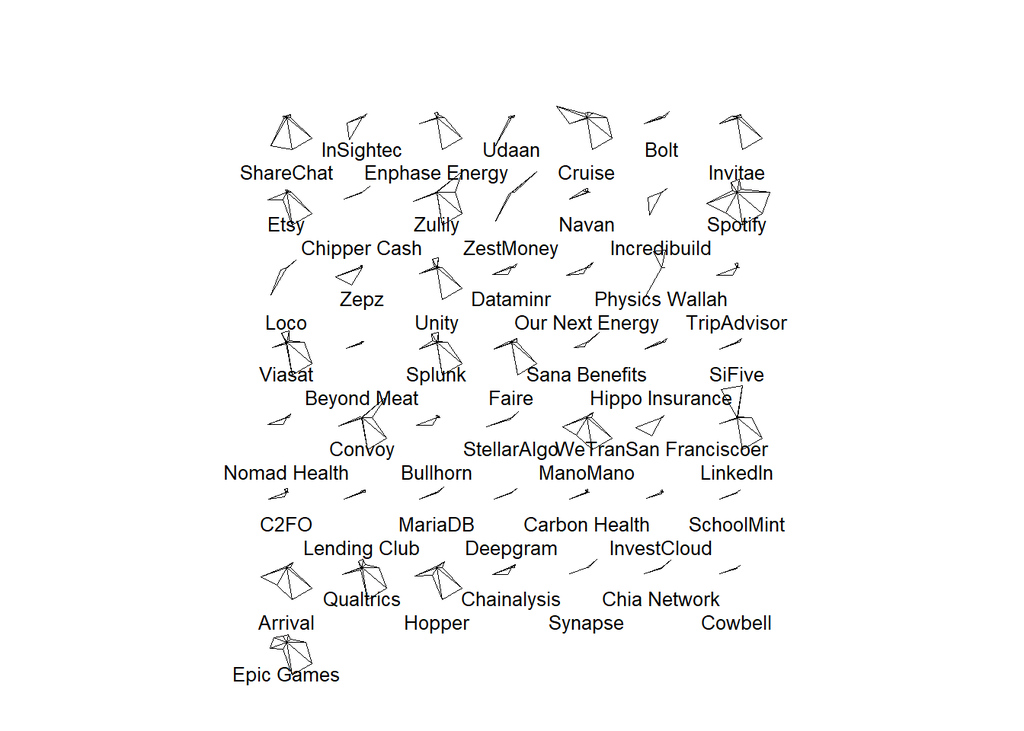

```r
stars(sc_dataset)
```

```r
correlation_matrix <- cor(sc_dataset[,1:8])
correlation_matrix
```

```
##                          Laid_Off  Percentage Before_Layoffs After_layoffs
## Laid_Off               1.00000000  0.12183480     0.54550795   0.486733850
## Percentage             0.12183480  1.00000000    -0.32685808  -0.350619262
## Before_Layoffs         0.54550795 -0.32685808     1.00000000   0.997644623
## After_layoffs          0.48673385 -0.35061926     0.99764462   1.000000000
## Money_Raised_in_._mil  0.46999114 -0.03866492     0.11967718   0.086266372
## lat                    0.26406099 -0.01806099    -0.07351675  -0.098299142
## lng                   -0.07280321  0.04048470    -0.01082477  -0.005254405
## layoff                 0.70599886  0.08903579     0.41771690   0.377590817
##                       Money_Raised_in_._mil          lat          lng
## Laid_Off                        0.469991136  0.264060988 -0.072803208
## Percentage                     -0.038664917 -0.018060991  0.040484705
## Before_Layoffs                  0.119677176 -0.073516747 -0.010824768
## After_layoffs                   0.086266372 -0.098299142 -0.005254405
## Money_Raised_in_._mil           1.000000000  0.004431795 -0.088698006
## lat                             0.004431795  1.000000000 -0.426625648
## lng                            -0.088698006 -0.426625648  1.000000000
## layoff                          0.354723261  0.216033622 -0.084462957
##                            layoff
## Laid_Off               0.70599886
## Percentage             0.08903579
## Before_Layoffs         0.41771690
## After_layoffs          0.37759082
## Money_Raised_in_._mil  0.35472326
## lat                    0.21603362
## lng                   -0.08446296
## layoff                 1.00000000
```

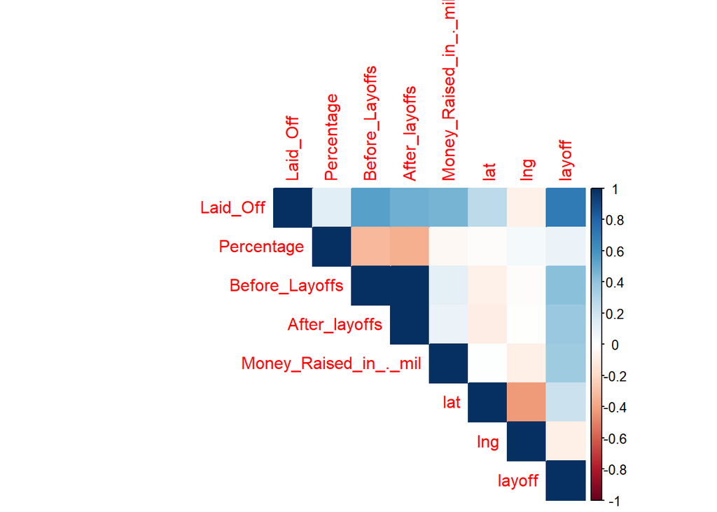

```r
corrplot(cor(sc_dataset[,1:8]), type = "upper", method = "color")
```

• The correlation matrix shows us a correlation between the columns in both cases.

• Hence, Principal Component Analysis (PCA) can be used to reduce the number of columns for the analysis.

# PCA :

```r
# PCA

sc_dataset_pca <- prcomp(sc_dataset[,1:7],scale=TRUE)
sc_dataset_pca
```

```
## Standard deviations (1, .., p=7):
## [1] 1.5988827585 1.2479910442 1.0997465486 0.9336974799 0.7865917285
## [6] 0.4314304827 0.0001194341
##
## Rotation (n x k) = (7 x 7):
##                               PC1        PC2        PC3         PC4         PC5
## Laid_Off               0.44756772 -0.3295601  0.3865914  0.16957176  0.20431658
## Percentage            -0.22859480 -0.2106132  0.5708643  0.60863447 -0.31048077
## Before_Layoffs         0.59495123  0.1626940 -0.0832348  0.18721734 -0.09675717
## After_layoffs          0.58347596  0.1965931 -0.1183420  0.18127609 -0.11756615
## Money_Raised_in_._mil  0.22205269 -0.2903846  0.4833802 -0.70435126 -0.06954819
## lat                    0.02895236 -0.6285861 -0.3125548  0.18426890  0.58250265
## lng                   -0.05357944  0.5499729  0.4151882  0.05322054  0.70322571
##                              PC6           PC7
## Laid_Off              -0.6840478 -5.656034e-02
## Percentage             0.3326654  1.939548e-05
## Before_Layoffs         0.2217901  7.204391e-01
## After_layoffs          0.2871426 -6.912079e-01
## Money_Raised_in_._mil  0.3629949 -5.291986e-06
## lat                    0.3648100 -3.021362e-05
## lng                    0.1578574  3.478138e-05
```

```r
summary(sc_dataset_pca)
```

```
## Importance of components:
##                           PC1    PC2    PC3    PC4     PC5     PC6       PC7
## Standard deviation     1.5989 1.2480 1.0997 0.9337 0.78659 0.43143 0.0001194
## Proportion of Variance 0.3652 0.2225 0.1728 0.1245 0.08839 0.02659 0.0000000
## Cumulative Proportion  0.3652 0.5877 0.7605 0.8850 0.97341 1.00000 1.0000000
```

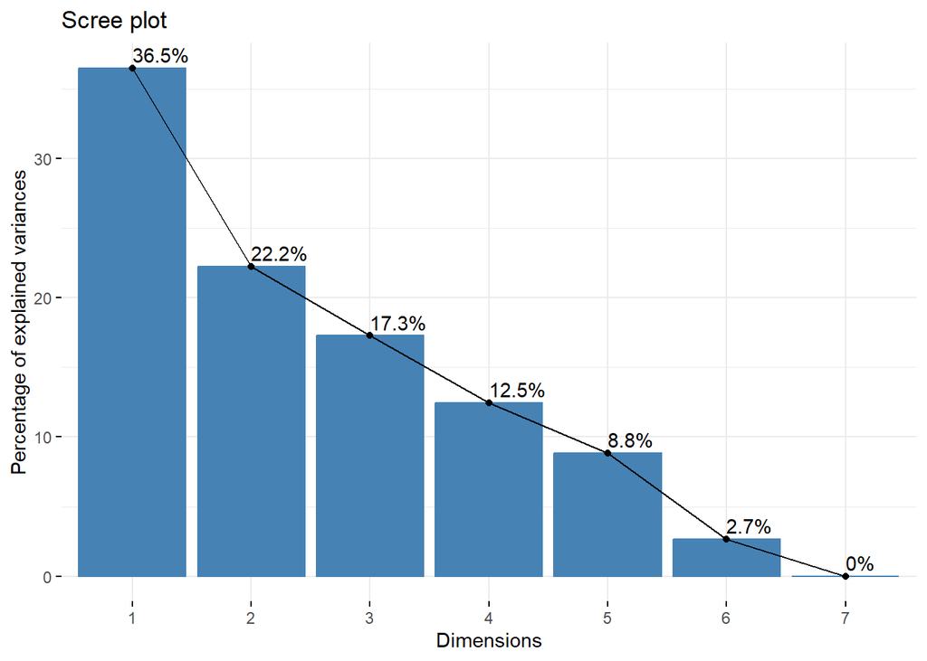

```r
fviz_eig(sc_dataset_pca, addlabels = TRUE)
```

```r
#plot(sc_dataset, xlab = "Component number", ylab = "Component variance", main = "Scree diagram")
```

• The scree diagram shows us that sum of the first 2 principal components is less than 70%.

• So, we cannot move forward using PCA for column reduction.

• We now move on to check EFA for this dataset.

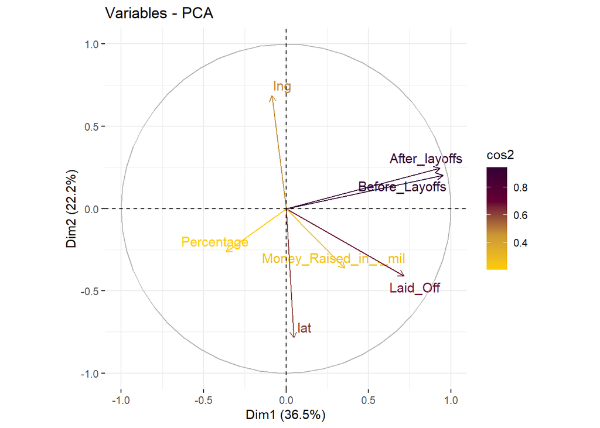

```r
fviz_pca_var(sc_dataset_pca,col.var = "cos2",
             gradient.cols = c("#FFCC00", "#CC9933", "#660033", "#330033"),
             repel = TRUE)
```

# FACTOR ANALYSIS :

```r
# EFA


fit.pc <- principal(sc_dataset[,1:7], nfactors=4, rotate="varimax")
fit.pc
```

```
## Principal Components Analysis
## Call: principal(r = sc_dataset[, 1:7], nfactors = 4, rotate = "varimax")
## Standardized loadings (pattern matrix) based upon correlation matrix
##                         RC1   RC2   RC4   RC3   h2    u2 com
## Laid_Off               0.64  0.22  0.52  0.39 0.89 0.113 2.9
## Percentage            -0.22 -0.05 -0.02  0.93 0.92 0.080 1.1
## Before_Layoffs         0.98 -0.04  0.05 -0.16 0.99 0.015 1.1
## After_layoffs          0.97 -0.06  0.01 -0.20 0.98 0.024 1.1
## Money_Raised_in_._mil  0.04  0.01  0.98 -0.05 0.97 0.028 1.0
## lat                    0.00  0.87  0.00  0.12 0.77 0.235 1.0
## lng                    0.02 -0.82 -0.06  0.14 0.69 0.311 1.1
##
##                        RC1  RC2  RC4  RC3
## SS loadings           2.35 1.47 1.25 1.12
## Proportion Var        0.34 0.21 0.18 0.16
## Cumulative Var        0.34 0.55 0.72 0.89
## Proportion Explained  0.38 0.24 0.20 0.18
## Cumulative Proportion 0.38 0.62 0.82 1.00
##
## Mean item complexity =  1.3
## Test of the hypothesis that 4 components are sufficient.
##
## The root mean square of the residuals (RMSR) is  0.08
##  with the empirical chi square  12.26  with prob <  NA
##
## Fit based upon off diagonal values = 0.95
```

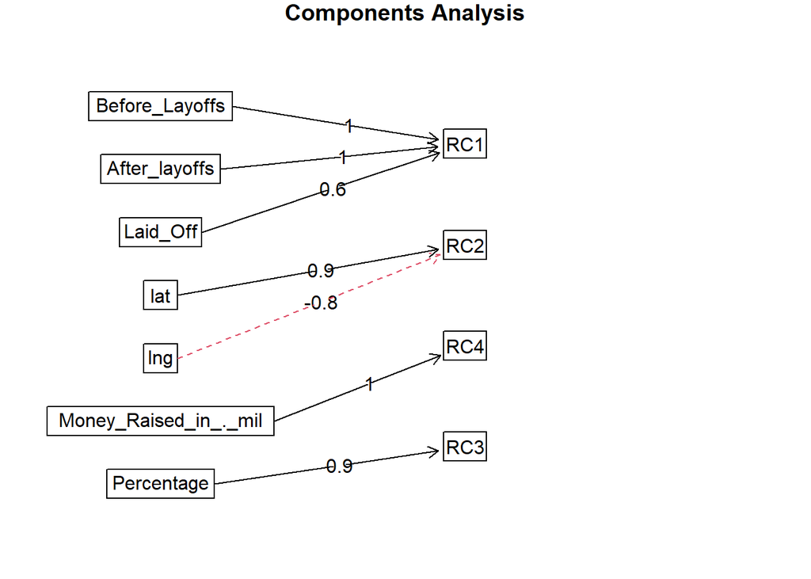

```r
fa.diagram(fit.pc)
```

```r
vss(sc_dataset[,1:7])
```

[output not shown]

[output not shown]

```
## In factor.stats, I could not find the RMSEA upper bound . Sorry about that
```

[output not shown]

```
## In factor.stats, I could not find the RMSEA upper bound . Sorry about that
```

[output not shown]

[output not shown]

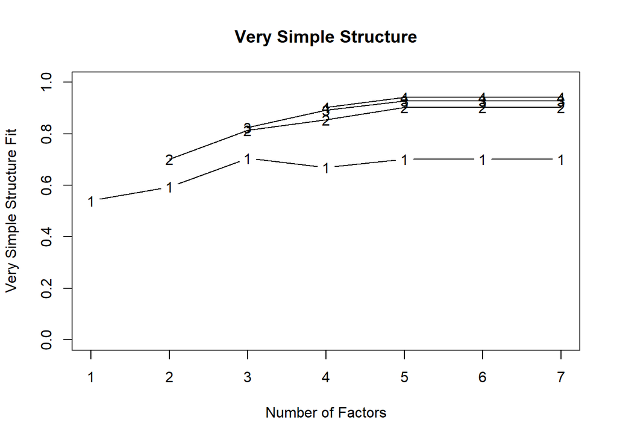

```
##
## Very Simple Structure
## Call: vss(x = sc_dataset[, 1:7])
## VSS complexity 1 achieves a maximimum of 0.71  with  3  factors
## VSS complexity 2 achieves a maximimum of 0.9  with  5  factors
##
## The Velicer MAP achieves a minimum of 0.2  with  1  factors
## BIC achieves a minimum of  581.18  with  1  factors
## Sample Size adjusted BIC achieves a minimum of  625.12  with  1  factors
##
## Statistics by number of factors
##   vss1 vss2  map dof   chisq     prob sqresid  fit  RMSEA     BIC   SABIC
## 1 0.54 0.00 0.20  14     636 1.2e-126    5.33 0.54   0.94     581     625
## 2 0.59 0.70 0.22   8  368576  0.0e+00    3.47 0.70  30.35  368545  368570
## 3 0.71 0.81 0.29   3 1808016  0.0e+00    2.03 0.83 109.79 1808005 1808014
## 4 0.67 0.86 0.56  -1     463       NA    1.12 0.90     NA      NA      NA
## 5 0.70 0.90 1.00  -4     471       NA    0.67 0.94     NA      NA      NA
## 6 0.70 0.90  NaN  -6     463       NA    0.67 0.94     NA      NA      NA
## 7 0.70 0.90   NA  -7     456       NA    0.67 0.94     NA      NA      NA
##   complex  eChisq    SRMR eCRMS  eBIC
## 1     1.0 5.1e+01 0.15619 0.191  -3.5
## 2     1.2 1.9e+01 0.09621 0.156 -11.9
## 3     1.1 2.9e+00 0.03690 0.098  -8.9
## 4     1.4 1.0e-01 0.00705    NA    NA
## 5     1.5 6.3e-04 0.00055    NA    NA
## 6     1.5 6.3e-04 0.00055    NA    NA
## 7     1.5 6.3e-04 0.00055    NA    NA
```

Defining the factors obtained :

- RC1: Layoff Metrics

RC1 focuses on essential metrics directly related to layoffs within tech companies. “Before_Layoffs” represents the number of employees before layoffs, “After_Layoffs” indicates the number of employees after layoffs occurred, and “Laid_Off” signifies the actual number of employees laid off. This RCS provides crucial information about the scale and impact of layoffs within the dataset.

- RC2: Geospatial Coordinates

RC2 encompasses geospatial coordinates associated with the location of tech companies. “lat” denotes the latitude coordinate, and “lng” represents the longitude coordinate. This RCS facilitates geospatial analysis and visualization, allowing for insights into the geographic distribution and clustering of tech companies affected by layoffs.

# CLUSTERING :

```r
# CLUSTERING

efa_data <- as.data.frame(fit.pc$scores)
efa_data
```

```
##                               RC1         RC2          RC4          RC3
## ShareChat             -0.30258876 -2.70077408  0.560037741 -0.250795453
## InSightec             -0.47717099 -1.16957635 -0.066656297 -0.012142344
## Enphase Energy         0.35306635  0.47320697 -0.270547814 -0.390773486
## Udaan                 -0.44604135 -2.71528908  0.424585732 -0.471284681
## Cruise                -0.24174986  0.09354921  5.881858093 -0.316714130
## Bolt                  -0.57024360  0.38143684  0.085210854  0.004868463
## Invitae               -0.34380292  0.38201132  0.632353179 -0.463738971
## Etsy                  -0.04070619  0.24908493 -0.333627263 -0.346496107
## Chipper Cash          -0.67126697  0.37774198 -0.398303704  0.093067822
## Zulily                 0.28241193  1.08713119 -0.118844102  3.770136683
## ZestMoney             -0.35498470 -2.81867218 -0.406499943  3.041655169
## Navan                 -0.10470679  0.34302519  0.400541674 -0.995755092
## Incredibuild          -0.54199516 -1.20132890 -0.364775866 -0.037293937
## Spotify                2.52661000  0.82931725  0.970867618  1.630296226
## Loco                  -0.53600383 -2.31598690 -0.294689809  0.539607478
## Zepz                  -0.31419844  0.22676330 -0.307540114 -0.700766509
## Unity                  0.90520453  0.38170689 -0.070860832 -0.868025270
## Dataminr              -0.45403213  0.18871422  0.023579712 -0.159026500
## Our Next Energy       -0.46674623  0.37059741 -0.293380965  0.055247673
## Physics Wallah         2.16252163 -3.07247587 -0.708538242 -0.973926992
## TripAdvisor            0.12933351  0.29036962 -0.516427834 -0.727023829
## Viasat                 1.70463485  0.21711266  0.004486417  0.058145147
## Beyond Meat           -0.48952401  0.18612610 -0.319872509 -0.812394729
## Splunk                 1.12860319  0.40528752  0.525046729 -0.547684793
## Faire                 -0.33908153  0.41316041  0.341096304 -0.226008250
## Sana Benefits         -0.56132013 -0.28019550 -0.430319569  0.810026154
## Hippo Insurance       -0.55892910  0.37254823  0.110538471 -0.353234855
## SiFive                -0.47077941  0.40271795 -0.241730201 -0.269001576
## Nomad Health          -0.42916778  0.21784497 -0.327456244 -0.242817608
## Convoy                -0.12346492  0.94599552 -0.066624249  3.271401400
## Bullhorn              -0.21196748  0.30934725 -0.413248353 -0.495759784
## StellarAlgo           -0.61756605  1.12041925 -0.608070856  0.078359018
## ManoMano              -0.25872264  0.07647593 -0.160529204  0.414641873
## WeTranSan Franciscoer -0.50887186  0.26358563 -0.517889726 -0.303917885
## LinkedIn               4.80923197  0.28865589 -1.120716169 -0.563769858
## C2FO                  -0.07027842  0.26360876 -0.289571783 -0.941918630
## Lending Club          -0.31729374  0.44797265 -0.205827730 -0.450746348
## MariaDB               -0.56618290  0.38962496 -0.335919738 -0.011836967
## Deepgram              -0.66138424  0.43001448 -0.420837061 -0.380914529
## Carbon Health         -0.14657936  0.43429974 -0.236693895 -0.894811521
## InvestCloud           -0.29785046  0.18753024 -0.368811290 -0.914140464
## SchoolMint            -0.63463808  0.45492554 -0.421879748 -0.594300352
## Arrival               -0.30011592  0.24900627 -0.235652235  0.403480441
## Qualtrics              1.15555308  0.67365210  0.060033368  0.308970205
## Hopper                -0.30498205  0.49473866 -0.121728373  0.420867939
## Chainalysis           -0.36341982  0.21597275 -0.186350253 -0.308354169
## Synapse               -0.54970010  0.42604333 -0.471744812  0.456192290
## Chia Network          -0.63334355  0.38116804 -0.497033032  0.276037009
## Cowbell               -0.63950054  0.41851083 -0.369882570 -0.673407726
## Epic Games             0.76373099 -0.08670313  2.498846493  0.065782355
```

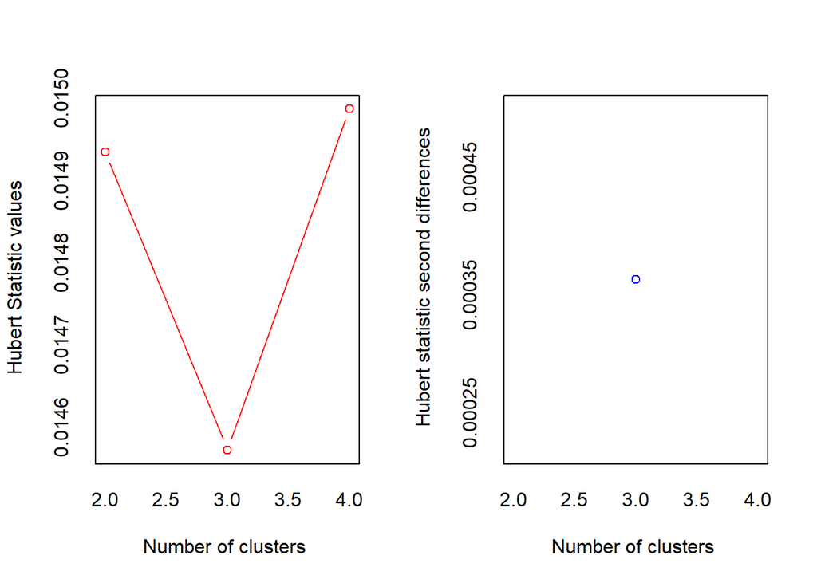

```
## *** : The Hubert index is a graphical method of determining the number of clusters.
##                 In the plot of Hubert index, we seek a significant knee that corresponds to a
##                 significant increase of the value of the measure i.e the significant peak in Hubert
##                 index second differences plot.
##
```

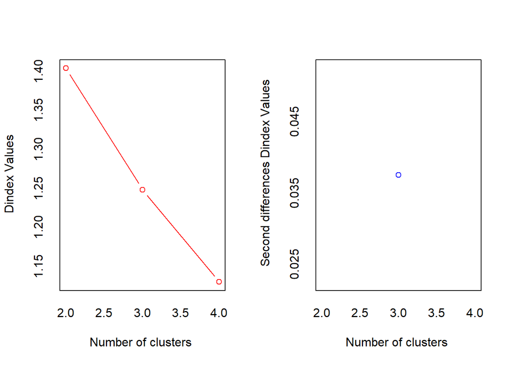

```
## *** : The D index is a graphical method of determining the number of clusters.
##                 In the plot of D index, we seek a significant knee (the significant peak in Dindex
##                 second differences plot) that corresponds to a significant increase of the value of
##                 the measure.
##
## * Among all indices:
## * 11 proposed 2 as the best number of clusters
## * 9 proposed 3 as the best number of clusters
## * 4 proposed 4 as the best number of clusters
##
##                    ***** Conclusion *****
##
## * According to the majority rule, the best number of clusters is  2
##
##
```

```r
matstd_sm <- scale(efa_data)

#fviz_nbclust(matstd_sm, kmeans, method = "gap_stat")

res.hc <- matstd_sm %>% scale() %>% dist(method = "euclidean") %>%
  hclust(method = "ward.D2")

res.nbclust <- matstd_sm %>% scale() %>% NbClust(distance = "euclidean", min.nc = 2, max.nc = 4, method = "complete", index ="all")
```

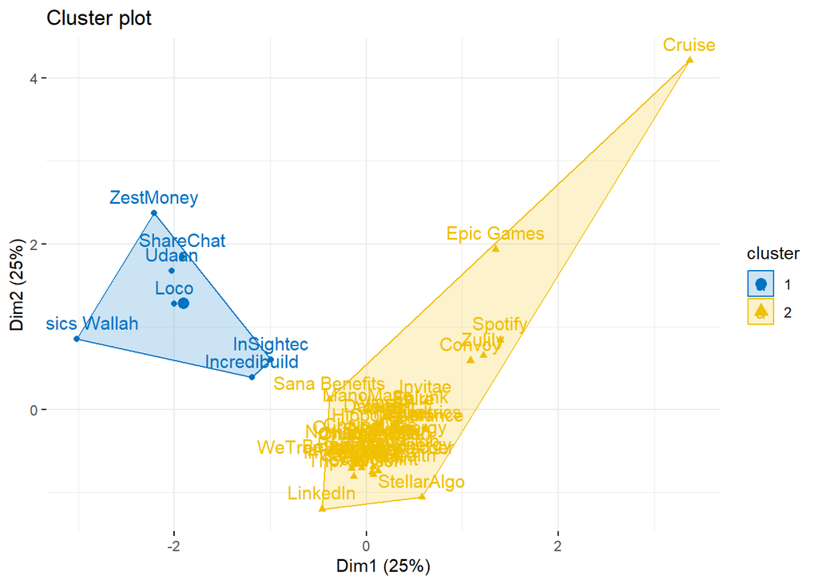

```r
#fviz_nbclust(res.nbclust, ggtheme = theme_minimal())

km.res <- kmeans(matstd_sm, 2, nstart = 10)

fviz_cluster(km.res, data = matstd_sm,
             ellipse.type = "convex",
             palette = "jco",
             ggtheme = theme_minimal())
```

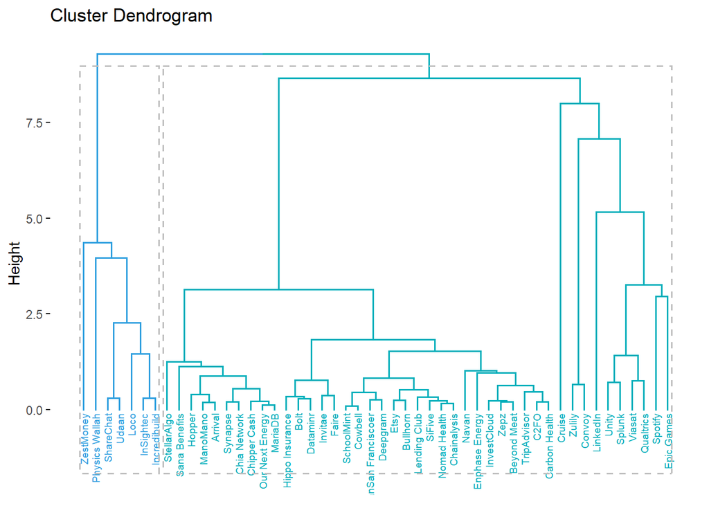

```r
dist.sc_dataset <- dist(matstd_sm, method="euclidean")



fviz_dend(res.hc, k = 2, # Cut in four groups
          cex = 0.5, # label size
          k_colors = c("#2E9FDF", "#00AFBB", "#E7B800", "#FC4E07"),
          color_labels_by_k = TRUE, # color labels by groups
          rect = TRUE # Add rectangle around groups
)
```

```r
Clustered <- ifelse(km.res$cluster > 1.5, "No layoff", "Layoff")
Actual <- ifelse(sc_dataset$layoff == 1, "Layoff", "No Layoff")
confusion_mat <- table(Clustered, Actual)
confusion_mat
```

```
##            Actual
## Clustered   Layoff No Layoff
##   Layoff         1         6
##   No layoff     17        26
```

```r
accuracy <- sum(diag(confusion_mat)) / sum(confusion_mat)
precision <- confusion_mat[2, 2] / sum(confusion_mat[, 2])
recall <- confusion_mat[2, 2] / sum(confusion_mat[2, ])
cat("Accuracy:", round(accuracy, 3), "\n")
```

```
## Accuracy: 0.54
```

```r
cat("Precision:", round(precision, 3), "\n")
```

```
## Precision: 0.812
```

```r
cat("Recall:", round(recall, 3), "\n")
```

```
## Recall: 0.605
```

Clustering analysis has been conducted on the dataset, resulting in the formation of two distinct groups or clusters.

# REGRESSION :

```r
wdbc <- read.csv("/Users/parul/OneDrive/Desktop/MVA/Layoff_Data.csv")
features <- c("Laid_Off", "Percentage", "Before_Layoff", "After_Layoff", "Money_raised", "lat", "lng", "laid_yes_no", "layoff")
names(wdbc) <- c("Company", "Laid_Off", "Percentage", "Before_Layoff", "After_Layoff", "Money_raised", "lat", "lng", "laid_yes_no", "layoff")
wdbc<- wdbc
wdbc.data <- as.matrix(wdbc[,c(2:8)])
row.names(wdbc.data) <- wdbc$Company
wdbc_raw <- cbind(wdbc.data, as.numeric(as.factor(wdbc$laid_yes_no))-1)
colnames(wdbc_raw)[8] <- "LayoffYesNo"
smp_size_raw <- floor(0.70 * nrow(wdbc_raw))
train_ind_raw <- sample(nrow(wdbc_raw), size = smp_size_raw)
train_raw.df <- as.data.frame(wdbc_raw[train_ind_raw, ])
test_raw.df <- as.data.frame(wdbc_raw[-train_ind_raw, ])
```

Now divided the dataset into training and testing data for regression analysis. We consider the training and testing data with a 70-30 split.

# MULTIPLE REGRESSION :

- Multiple regression is a statistical technique used to understand the relationship between one dependent variable and two or more independent variables.
- It aims to predict the value of the dependent variable based on the values of the independent variables.

```r
# MULTIPLE REGRESSION
#fit <- lm(TroubleInSleep~Instagram + Snapchat + Twitter, data=sc_dataset)
x_sm <- cbind(train_ind_raw,train_raw.df[, -9])

fit <- lm( LayoffYesNo~ ., data = train_raw.df)

summary(fit)
```

```
##
## Call:
## lm(formula = LayoffYesNo ~ ., data = train_raw.df)
##
## Residuals:
##      Min       1Q   Median       3Q      Max
## -0.55480 -0.20582 -0.12162  0.05378  0.65648
##
## Coefficients:
##                 Estimate Std. Error t value Pr(>|t|)
## (Intercept)   -2.976e-01  3.552e-01  -0.838    0.409
## Laid_Off       2.261e-03  8.799e-02   0.026    0.980
## Percentage     2.326e-03  3.566e-03   0.652    0.520
## Before_Layoff -1.559e-03  8.799e-02  -0.018    0.986
## After_Layoff   1.587e-03  8.799e-02   0.018    0.986
## Money_raised   2.235e-05  2.998e-05   0.745    0.462
## lat            8.414e-03  8.263e-03   1.018    0.318
## lng           -2.252e-04  1.056e-03  -0.213    0.833
##
## Residual standard error: 0.3604 on 27 degrees of freedom
## Multiple R-squared:  0.5707, Adjusted R-squared:  0.4594
## F-statistic: 5.128 on 7 and 27 DF,  p-value: 0.0008415
```

```r
coefficients(fit)
```

```
##   (Intercept)      Laid_Off    Percentage Before_Layoff  After_Layoff
## -2.976237e-01  2.260917e-03  2.326458e-03 -1.558893e-03  1.587178e-03
##  Money_raised           lat           lng
##  2.235105e-05  8.413685e-03 -2.251660e-04
```

```r
residuals(fit)
```

```
##                 Unity                  Loco        Enphase Energy
##            0.54794081            0.02725308            0.59357333
##                 Navan               Synapse       Our Next Energy
##           -0.28542621           -0.20686671           -0.24483753
##               MariaDB                Splunk           TripAdvisor
##           -0.18158847            0.34339572           -0.25674795
##          Incredibuild WeTranSan Franciscoer                  C2FO
##           -0.04438133           -0.20010956           -0.20096214
##              Dataminr             ZestMoney            Epic Games
##           -0.25498684           -0.13626538            0.05870529
##         Carbon Health             Qualtrics           StellarAlgo
##           -0.21258812            0.20487854           -0.23935232
##              Deepgram                Cruise              LinkedIn
##           -0.11297233           -0.15130154           -0.12162380
##          Chipper Cash                  Zepz                Zulily
##           -0.14266972           -0.21871952            0.04355537
##               Arrival               Cowbell           Beyond Meat
##            0.63462285           -0.10281994           -0.10363273
##               Spotify            SchoolMint           InvestCloud
##           -0.55480350           -0.10658550           -0.12749988
##              ManoMano                Hopper                 Udaan
##            0.63221434            0.62005111            0.04885022
##                SiFive               Invitae
##           -0.20478077            0.65648112
```

```r
probabilities_sm2 <- predict(fit, newdata = test_raw.df, type = "response")

predicted_sm2 <- ifelse(probabilities_sm2 > 0.5, "Yes", "No")
actual_sm <- ifelse(test_raw.df$LayoffYesNo == 1, "Yes", "No")
confusion_sm2 <- table(predicted_sm2, actual_sm)
confusion_sm2
```

```
##              actual_sm
## predicted_sm2 No Yes
##           No  10   3
##           Yes  0   2
```

```r
roc_sm <- roc(test_raw.df$LayoffYesNo, probabilities_sm2)
```

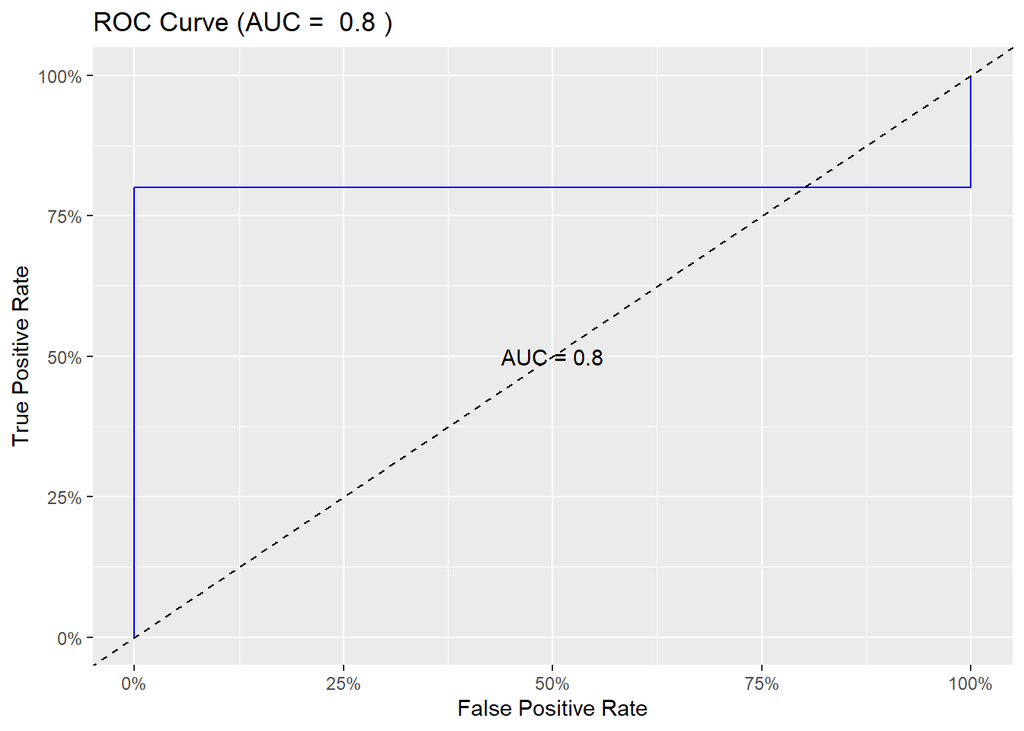

```r
auc_sm <- auc(roc_sm)

ggroc(roc_sm, color = "blue", legacy.axes = TRUE) +
  geom_abline(intercept = 0, slope = 1, linetype = "dashed") +
  scale_x_continuous(labels = scales::percent_format()) +
  scale_y_continuous(labels = scales::percent_format()) +
  labs(x = "False Positive Rate", y = "True Positive Rate",
       title = paste("ROC Curve (AUC = ", round(auc_sm, 2), ")")) +
  annotate("text", x = 0.5, y = 0.5, label = paste0("AUC = ", round(auc_sm, 2)))
```

```r
threshold<-0.5
predicted <- predict(fit, newdata = test_raw.df)

predicted_category <- ifelse(predicted > threshold, "No Layoff", "Layoff")

# Convert actual values to binary categories
actual_category <- ifelse(test_raw.df$LayoffYesNo == 1, "No Layoff", "Layoff")

# Create a confusion matrix
confusion_mat <- table(predicted_category, actual_category)

# Calculate accuracy
accuracy <- sum(diag(confusion_mat)) / sum(confusion_mat)
accuracy
```

```
## [1] 0.8
```

# LOGISTIC REGRESSION :

- Logistic regression is a statistical method used for binary classification problems. It predicts the probability that a given observation belongs to one of two classes.
- It models the relationship between a binary dependent variable and one or more independent variables.

```r
# Logistic Regression

logistic_sm <- glm(LayoffYesNo ~ ., data = train_raw.df, family = 'binomial')
summary(logistic_sm)
```

```
##
## Call:
## glm(formula = LayoffYesNo ~ ., family = "binomial", data = train_raw.df)
##
## Coefficients:
##                 Estimate Std. Error z value Pr(>|z|)
## (Intercept)   -2.811e+02  3.650e+05  -0.001    0.999
## Laid_Off       2.630e+01  8.343e+04   0.000    1.000
## Percentage     1.417e+00  6.624e+03   0.000    1.000
## Before_Layoff -2.597e+01  8.325e+04   0.000    1.000
## After_Layoff   2.598e+01  8.324e+04   0.000    1.000
## Money_raised   1.398e-02  4.660e+01   0.000    1.000
## lat            3.729e+00  7.450e+03   0.001    1.000
## lng           -1.718e-01  9.035e+02   0.000    1.000
##
## (Dispersion parameter for binomial family taken to be 1)
##
##     Null deviance: 4.6180e+01  on 34  degrees of freedom
## Residual deviance: 3.7785e-09  on 27  degrees of freedom
## AIC: 16
##
## Number of Fisher Scoring iterations: 25
```

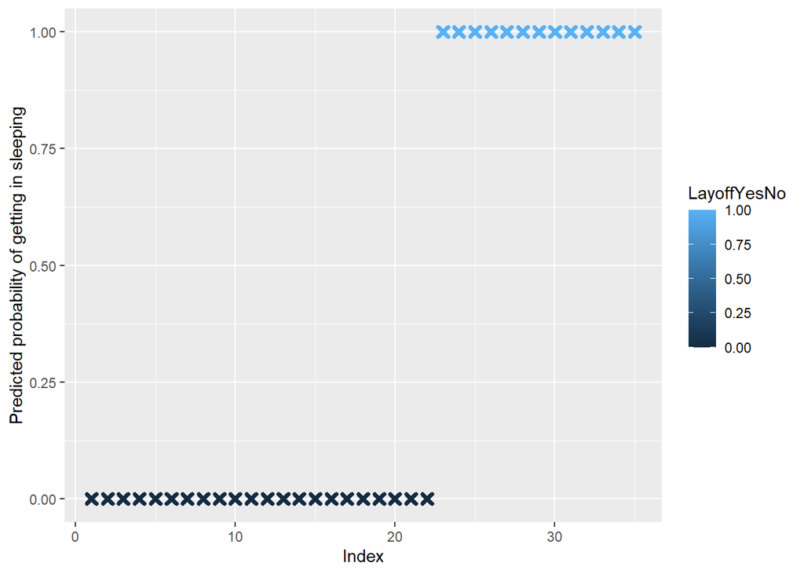

```r
predicted.data <- data.frame(probability.of.hd=logistic_sm$fitted.values,LayoffYesNo=train_raw.df$LayoffYesNo)
predicted.data <- predicted.data[order(predicted.data$probability.of.hd, decreasing=FALSE),]
predicted.data$rank <- 1:nrow(predicted.data)

ggplot(data=predicted.data, aes(x=rank, y=probability.of.hd)) +
  geom_point(aes(color=LayoffYesNo), alpha=1, shape=4, stroke=2) +
  xlab("Index") +
  ylab("Predicted probability of getting in sleeping")
```

```r
probabilities_sm2 <- predict(logistic_sm, newdata = test_raw.df, type = "response")

predicted_sm2 <- ifelse(probabilities_sm2 > 0.5, "Yes", "No")
actual_sm <- ifelse(test_raw.df$LayoffYesNo == 1, "Yes", "No")
confusion_sm2 <- table(predicted_sm2, actual_sm)
confusion_sm2
```

```
##              actual_sm
## predicted_sm2 No Yes
##           No  10   2
##           Yes  0   3
```

```r
accuracy2 <- sum(diag(confusion_sm2)) / sum(confusion_sm2)
precision2 <- confusion_sm2[2, 2] / sum(confusion_sm2[, 2])
recall2 <- confusion_sm2[2, 2] / sum(confusion_sm2[2, ])
cat("Accuracy:", round(accuracy2, 3), "\n")
```

```
## Accuracy: 0.867
```

```r
cat("Precision:", round(precision2, 3), "\n")
```

```
## Precision: 0.6
```

```r
cat("Recall:", round(recall2, 3), "\n")
```

```
## Recall: 1
```

```r
probabilities <- predict(logistic_sm, newdata = test_raw.df, type = "response")

roc_sm <- roc(test_raw.df$LayoffYesNo, probabilities_sm2)
```

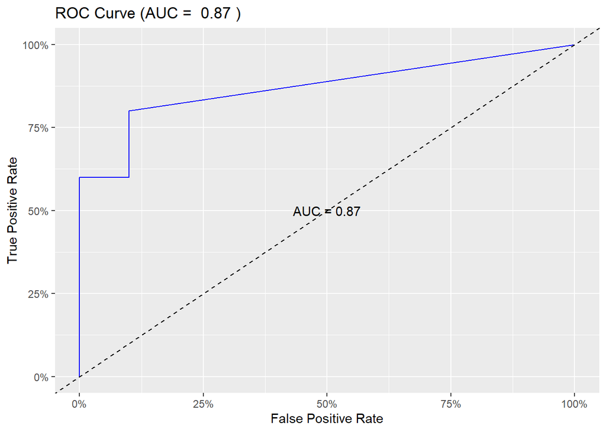

```r
auc_sm <- auc(roc_sm)

ggroc(roc_sm, color = "blue", legacy.axes = TRUE) +
  geom_abline(intercept = 0, slope = 1, linetype = "dashed") +
  scale_x_continuous(labels = scales::percent_format()) +
  scale_y_continuous(labels = scales::percent_format()) +
  labs(x = "False Positive Rate", y = "True Positive Rate",
       title = paste("ROC Curve (AUC = ", round(auc_sm, 2), ")")) +
  annotate("text", x = 0.5, y = 0.5, label = paste0("AUC = ", round(auc_sm, 2)))
```

These visualizations provide valuable insights into the logistic regression model’s performance by showcasing Accuracy and ROC Curve of the model.

# DISCRIMINANT :

- Discriminant analysis is a statistical method used for classification tasks that involve identifying which category or group a new observation belongs to based on one or more predictor variables (features).

```r
# DISCRIMINANT MODEL
wdbc_raw.lda <- lda(formula = LayoffYesNo ~ ., data = train_raw.df)
wdbc_raw.lda
```

```
## Call:
## lda(LayoffYesNo ~ ., data = train_raw.df)
##
## Prior probabilities of groups:
##         0         1
## 0.6285714 0.3714286
##
## Group means:
##    Laid_Off Percentage Before_Layoff After_Layoff Money_raised      lat
## 0  77.27273   20.45455      899.2273     822.2273     391.8636 36.52077
## 1 583.00000   22.38462     5245.0769    4662.0769    2509.8462 42.71970
##         lng
## 0 -68.90706
## 1 -84.60464
##
## Coefficients of linear discriminants:
##                         LD1
## Laid_Off       9.179369e-03
## Percentage     9.445470e-03
## Before_Layoff -6.329139e-03
## After_Layoff   6.443977e-03
## Money_raised   9.074572e-05
## lat            3.415974e-02
## lng           -9.141787e-04
```

```r
summary(wdbc_raw.lda)
```

```
##         Length Class  Mode
## prior    2     -none- numeric
## counts   2     -none- numeric
## means   14     -none- numeric
## scaling  7     -none- numeric
## lev      2     -none- character
## svd      1     -none- numeric
## N        1     -none- numeric
## call     3     -none- call
## terms    3     terms  call
## xlevels  0     -none- list
```

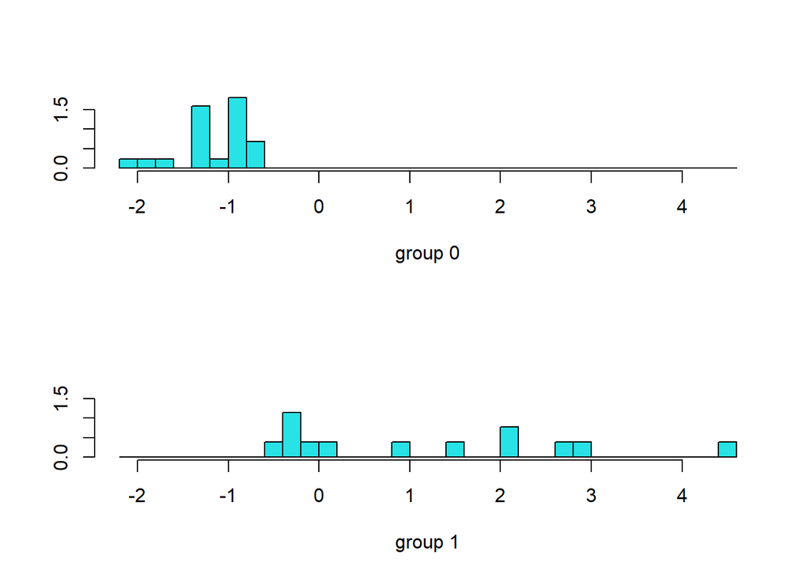

```r
plot(wdbc_raw.lda)
```

```r
predictions <- predict(wdbc_raw.lda, newdata = test_raw.df)
predicted_classes <- predictions$class
accuracy2 <- mean(predicted_classes == test_raw.df$LayoffYesNo)
accuracy2
```

```
## [1] 0.8
```

```r
wdbc_raw.lda.predict_train <- predict(wdbc_raw.lda, newdata = train_raw.df)
y<-wdbc_raw.lda.predict_train$class
wdbc_raw.lda.predict_train$x
```

```
##                               LD1
## Unity                  0.32736201
## Loco                  -1.61865581
## Enphase Energy         0.14209302
## Navan                 -0.34917139
## Synapse               -0.66812461
## Our Next Energy       -0.51396226
## MariaDB               -0.77075476
## Splunk                 1.15781934
## TripAdvisor           -0.46560570
## Incredibuild          -1.32781865
## WeTranSan Franciscoer -0.69555875
## C2FO                  -0.69209727
## Dataminr              -0.47275586
## ZestMoney             -0.95476749
## Epic Games             2.31366844
## Carbon Health         -0.64489555
## Qualtrics              1.72020198
## StellarAlgo           -0.53623233
## Deepgram              -1.04933776
## Cruise                 3.16630056
## LinkedIn               3.04580829
## Chipper Cash          -0.92876571
## Zepz                  -0.62000195
## Zulily                 2.37517742
## Arrival               -0.02456890
## Cowbell               -1.09055667
## Beyond Meat           -1.08725672
## Spotify                4.80452693
## SchoolMint            -1.07526839
## InvestCloud           -0.99035560
## ManoMano              -0.01479029
## Hopper                 0.03459265
## Udaan                 -1.70634067
## SiFive                -0.67659357
## Invitae               -0.11331395
```

```r
table(y,train_raw.df$LayoffYesNo)
```

```
##
## y    0  1
##   0 22  6
##   1  0  7
```

```r
wdbc_raw.lda.predict_test <- predict(wdbc_raw.lda, newdata = test_raw.df)
y<-wdbc_raw.lda.predict_test$class
wdbc_raw.lda.predict_test$x
```

```
##                        LD1
## ShareChat       -1.3480757
## InSightec       -1.0408995
## Bolt            -0.5149065
## Etsy            -0.2949124
## Physics Wallah  -0.7722008
## Viasat           1.7429872
## Faire           -0.1434870
## Sana Benefits   -0.8947512
## Hippo Insurance -0.6216723
## Nomad Health    -0.6716690
## Convoy           1.4911651
## Bullhorn        -0.5548050
## Lending Club    -0.5346392
## Chainalysis     -0.5424543
## Chia Network    -0.8790778
```

```r
table(y,test_raw.df$LayoffYesNo)
```

```
##
## y    0  1
##   0 10  3
##   1  0  2
```

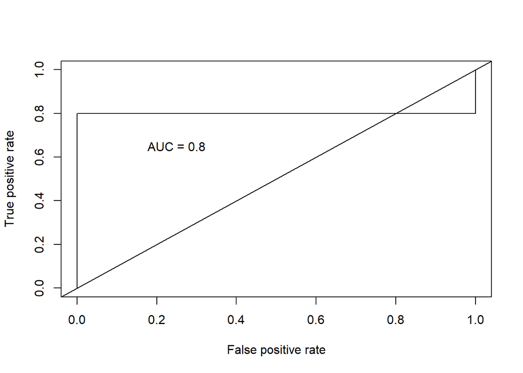

```r
wdbc_raw.lda.predict.posteriors <- as.data.frame(wdbc_raw.lda.predict_test$posterior)
pred <- prediction(wdbc_raw.lda.predict.posteriors[,2], test_raw.df$LayoffYesNo)
roc.perf = performance(pred, measure = "tpr", x.measure = "fpr")
auc.train <- performance(pred, measure = "auc")
auc.train <- auc.train@y.values
plot(roc.perf)
abline(a=0, b= 1)
text(x = .25, y = .65 ,paste("AUC = ", round(auc.train[[1]],3), sep = ""))
```

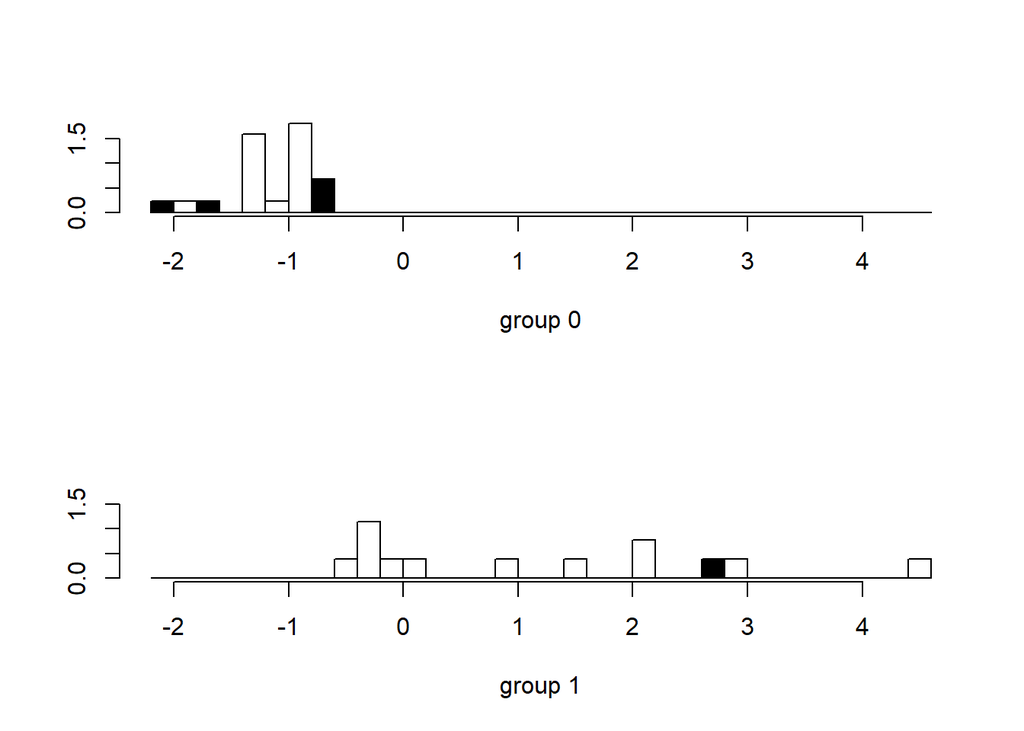

```r
plot(wdbc_raw.lda, col = as.integer(train_raw.df$LayoffYesNo))
```

The accuracy provides a clear visualization of how well the model performs overall.

The ROC curve offers deeper insights into the model’s sensitivity and specificity

# CONCLUSION :

# LEARNING :

- By examining historical data on layoffs, we can identify patterns and trends that may indicate factors contributing to layoffs in the technology industry.
- These models can be valuable tools for decision-making and risk management, allowing companies to proactively address potential workforce challenges and devise strategies to mitigate the impact of layoffs.

# TAKEAWAY:

The key takeaway from working on predicting the likelihood of future layoffs in tech companies based on historical data is the importance of leveraging data-driven insights for strategic decision-making and risk management. By harnessing the power of predictive analytics, organizations can anticipate and respond to workforce challenges more effectively, thereby enhancing resilience and adaptability in the dynamic technology industry landscape.